# World Cup 2018 matchs predictions

```r
library(dplyr)
library(zoo)
library(data.table)
library(ggplot2)
library(scales)
library(readr)
library(stringr)
library(Amelia)
library(randomForest)
library(corrplot)
library(Metrics)
library(vcd)
```

# Machine learning process

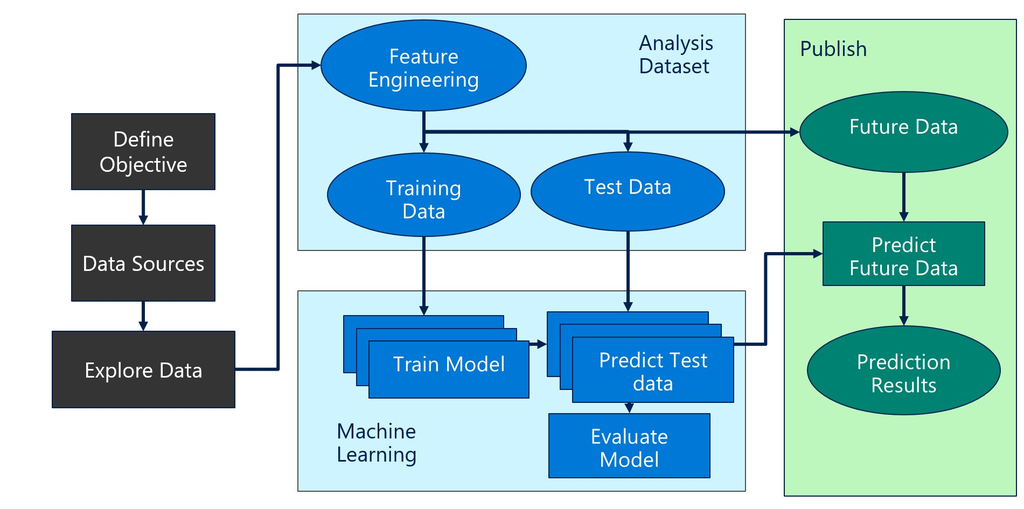

Machine learning process

# The objective

The ovjective is given a match between to team be able to predict the goal difference between the two teams at the end of the match. We will try to predict the `outcome` target. Let’s note that the `outcome` value can be zero (for draws), positive (whenever team1 wins) but also negative (whenever team2 wins the match).

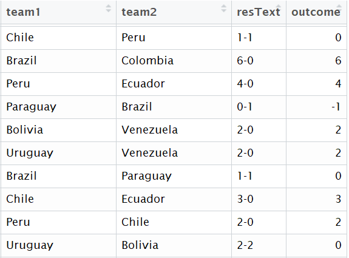

# Upload data

```r
matches_data <- read_csv("./matches.csv")
teams <- read_csv("./teams.csv")
head(matches)
```

[output not shown]

Let’s do some preprocessing cleaning of the train dataset. First we will remove duplicated data based on date, team 1, team 2.

```r
matches <- matches_data %>% distinct(.keep_all=TRUE, date, team1, team2)
matches$date <- as.POSIXct(strptime(matches$date, "%Y%m%d"), origin="1960-01-01", tz="UTC")
matches$match_id = seq.int(nrow(matches))
head(matches)
```

| date | team1 | team1Text | team2 | team2Text | resText | statText | venue | IdCupSeason | CupName | team1Score | team2Score | team1PenScore | team2PenScore | match_id |
| --- | --- | --- | --- | --- | --- | --- | --- | --- | --- | --- | --- | --- | --- | --- |
| 1956-09-30 | AUT | Austria | LUX | Luxembourg | 7-0 | NA | Ernst Happel Stadium - Vienna , Austria | 10 | FIFA World Cup™ Qualifier | 7 | 0 | NA | NA | 1 |
| 1956-10-03 | IRL | Republic of Ireland | DEN | Denmark | 2-1 | NA | DUBLIN - Dublin , Republic of Ireland | 10 | FIFA World Cup™ Qualifier | 2 | 1 | NA | NA | 2 |
| 1956-11-11 | FRA | France | BEL | Belgium | 6-3 | NA | Stade Olympique - Colombes , France | 10 | FIFA World Cup™ Qualifier | 6 | 3 | NA | NA | 3 |
| 1956-12-05 | ENG | England | DEN | Denmark | 5-2 | NA | Molineux - Wolverhampton , England | 10 | FIFA World Cup™ Qualifier | 5 | 2 | NA | NA | 4 |
| 1957-03-10 | ESP | Spain | SUI | Switzerland | 2-2 | NA | Santiago Bernabeu - Madrid , Spain | 10 | FIFA World Cup™ Qualifier | 2 | 2 | NA | NA | 5 |
| 1957-03-20 | NED | Netherlands | LUX | Luxembourg | 4-1 | NA | De Kuip - Rotterdam , Netherlands | 10 | FIFA World Cup™ Qualifier | 4 | 1 | NA | NA | 6 |

```r
summary(matches)
```

```
      date                        team1            team1Text            team2            team2Text           resText
 Min.   :1950-02-17 00:00:00   Length:33783       Length:33783       Length:33783       Length:33783       Length:33783
 1st Qu.:1983-03-20 00:00:00   Class :character   Class :character   Class :character   Class :character   Class :character
 Median :1997-06-29 00:00:00   Mode  :character   Mode  :character   Mode  :character   Mode  :character   Mode  :character
 Mean   :1993-11-04 01:14:30
 3rd Qu.:2007-02-07 00:00:00
 Max.   :2016-07-10 00:00:00

   statText            venue            IdCupSeason          CupName            team1Score       team2Score     team1PenScore
 Length:33783       Length:33783       Min.   :6.000e+00   Length:33783       Min.   : 0.000   Min.   : 0.000   Min.   : 0.00
 Class :character   Class :character   1st Qu.:3.881e+03   Class :character   1st Qu.: 1.000   1st Qu.: 0.000   1st Qu.: 3.00
 Mode  :character   Mode  :character   Median :2.764e+05   Mode  :character   Median : 1.000   Median : 1.000   Median : 4.00
                                       Mean   :9.950e+08                      Mean   : 1.709   Mean   : 1.095   Mean   : 4.06
                                       3rd Qu.:2.000e+09                      3rd Qu.: 2.000   3rd Qu.: 2.000   3rd Qu.: 5.00
                                       Max.   :2.000e+09                      Max.   :31.000   Max.   :22.000   Max.   :11.00
                                                                                                                NA's   :33318
 team2PenScore      match_id
 Min.   : 0.00   Min.   :    1
 1st Qu.: 3.00   1st Qu.: 8446
 Median : 4.00   Median :16892
 Mean   : 3.78   Mean   :16892
 3rd Qu.: 5.00   3rd Qu.:25338
 Max.   :12.00   Max.   :33783
 NA's   :33318
```

## Data exploration and Visualisation

Matches played by year in each competition. Later we will keep only the official matches

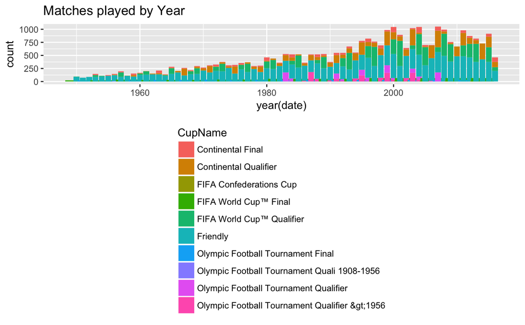

```r
matches %>%
  ggplot(mapping = aes(year(date))) +
    geom_bar(aes(fill=CupName)) +
    theme(legend.position = "bottom", legend.direction = "vertical") + ggtitle("Matches played by Year")
```

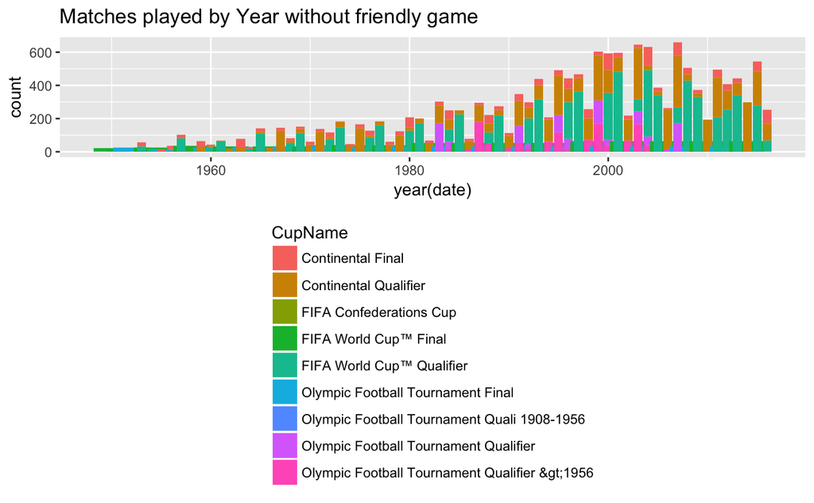

```r
matches %>% filter(CupName != "Friendly") %>%
  ggplot(mapping = aes(year(date))) +
    geom_bar(aes(fill=CupName)) +
    theme(legend.position = "bottom", legend.direction = "vertical") + ggtitle("Matches played by Year without friendly game")
```

Let’s plot the missing values in our dataset

[output not shown]

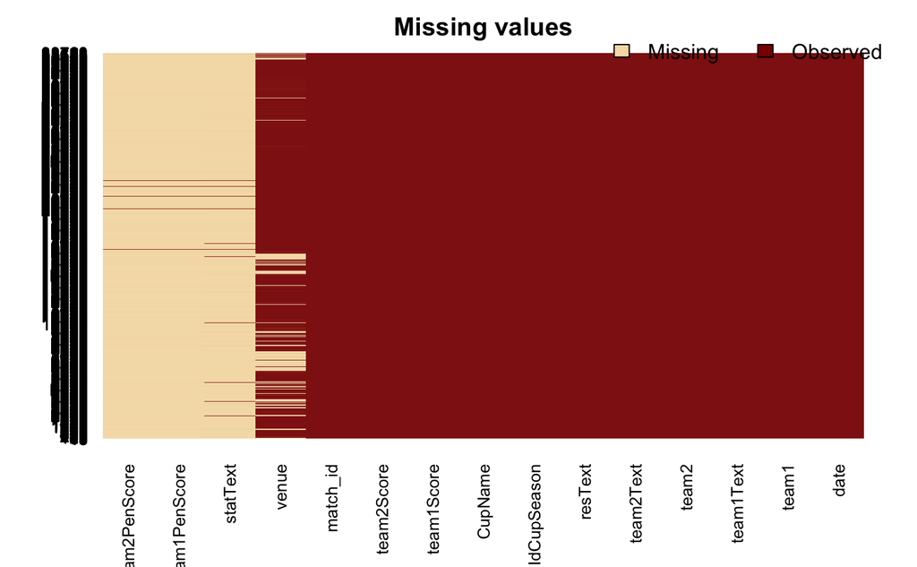

```r
Amelia::missmap(matches, main = "Missing values")
```

We switch the `team1`and `team2` because the `team1` had a lot of chance to win because it’s the home team

```r
summary(matches$team1Score - matches$team2Score)
```

```
    Min.  1st Qu.   Median     Mean  3rd Qu.     Max.
-22.0000  -1.0000   1.0000   0.6135   2.0000  31.0000
```

```r
set.seed(4342)
matches$switch = runif(nrow(matches), min = 0, max = 1)
matches <- bind_rows(
  matches %>% dplyr::filter(switch < 0.5),
  matches %>% dplyr::filter(switch >= 0.5) %>%
    dplyr::mutate(
      x_team2 = team2,
      team2 = team1,
      team1 = x_team2,

      x_team2Text = team2Text,
      team2Text = team1Text,
      team1Text = x_team2Text,
      x_resText = "",

      x_team2Score = team2Score,
      team2Score = team1Score,
      team1Score = x_team2Score,

      x_team2PenScore = team2PenScore,
      team2PenScore = team1PenScore,
      team1PenScore = x_team2PenScore
    ) %>%
    dplyr::select(
      date, team1, team1Text, team2, team2Text, resText, statText, venue, IdCupSeason, CupName, team1Score, team2Score, team1PenScore, team2PenScore, match_id, switch
    )
    ) %>%
  dplyr::arrange(date) %>%
  dplyr::select(-c(switch))
```

Let’s add some additional features, We start by defining the venue if the first team or the second team or a neutrak venue. The second step is to define the cup name, we introduce logical variables to specify the cup name (Friendly, Qual, Final, Confederations Cup)

```r
matches$team1Home <- mapply(grepl, pattern = matches$team1Text, x=matches$venue, MoreArgs = list(fixed=TRUE, ignore.case= FALSE))
matches$team2Home <- mapply(grepl, pattern = matches$team2Text, x=matches$venue, MoreArgs = list(fixed=TRUE, ignore.case= FALSE))
matches$neutralVenue <- !(matches$team1Home | matches$team2Home)
# text-matching the venue is not 100% accurate.
# some games get TRUE for both team1 and team2 (ex. Congo DR vs Congo)
# in this case, team1 is at home
matches$team2Home[(matches$team1Home == TRUE) & (matches$team2Home == TRUE)] <- FALSE
# game type: Friendly, Qualifier, Final Tournament
matches$friendly <- FALSE
matches$friendly[matches$CupName == "Friendly"] <- TRUE
matches$qualifier <- FALSE
matches$qualifier[matches$CupName %like% "Qual"] <- TRUE
matches$finaltourn <- FALSE
matches$finaltourn[matches$CupName %like% "Final"] <- TRUE
matches$finaltourn[matches$CupName %like% "Confederations Cup"] <- TRUE
head(matches)
```

| date | team1 | team1Text | team2 | team2Text | resText | statText | venue | IdCupSeason | CupName | team1Score | team2Score | team1PenScore | team2PenScore | match_id | team1Home | team2Home | neutralVenue | friendly | qualifier | finaltourn |
| --- | --- | --- | --- | --- | --- | --- | --- | --- | --- | --- | --- | --- | --- | --- | --- | --- | --- | --- | --- | --- |
| 1950-02-17 | GRE | Greece | EGY | Egypt | 2-0 | NA | CAIRO - Cairo , Egypt | 2000010101 | Friendly | 0 | 2 | NA | NA | 652 | FALSE | TRUE | FALSE | TRUE | FALSE | FALSE |
| 1950-02-25 | SLV | El Salvador | HAI | Haiti | 1-0 | NA | GUATEMALA CITY - Guatemala City , Guatemala | 2000010101 | Friendly | 1 | 0 | NA | NA | 653 | FALSE | FALSE | TRUE | TRUE | FALSE | FALSE |
| 1950-02-26 | SLV | El Salvador | CRC | Costa Rica | 0-1 | NA | GUATEMALA CITY - Guatemala City , Guatemala | 2000010101 | Friendly | 0 | 1 | NA | NA | 654 | FALSE | FALSE | TRUE | TRUE | FALSE | FALSE |
| 1950-02-27 | CUW | Curacao | CRC | Costa Rica | 1-0 | NA | GUATEMALA CITY - Guatemala City , Guatemala | 2000010101 | Friendly | 0 | 1 | NA | NA | 655 | FALSE | FALSE | TRUE | TRUE | FALSE | FALSE |
| 1950-02-27 | COL | Colombia | GUA | Guatemala | 2-1 | NA | GUATEMALA CITY - Guatemala City , Guatemala | 2000010101 | Friendly | 1 | 2 | NA | NA | 656 | FALSE | TRUE | FALSE | TRUE | FALSE | FALSE |
| 1950-02-28 | HAI | Haiti | NCA | Nicaragua | 2-4 | NA | GUATEMALA CITY - Guatemala City , Guatemala | 2000010101 | Friendly | 4 | 2 | NA | NA | 657 | FALSE | FALSE | TRUE | TRUE | FALSE | FALSE |

At this point, we’re going to eliminate friendly matches from the dataset.This decision is based on the observation that, with few exceptions, the main objective for a team playing a friendly is not to win it, but to evaluate its own players and tactics.

```r
matches <- matches %>% dplyr::filter(friendly == FALSE)
```

Up until this point we’ve only looked at individual matches. However, what we really need is to look at each team’s performance over its history. Building this dataset is simple: take each observation in matches - which has the form “team1 vs team2” - and produce two separate observations of the form “team1 played against team2” and “team2 played against team1” respectively.

```r
# transform the matches table into a team performance table, where each team being
# involved in a game is a separate observation (row)
teamperf <- bind_rows(
    (matches %>%
    dplyr::mutate(
      name = team1,
      opponentName = team2,
      homeVenue = team1Home,
      neutralVenue = neutralVenue,
      gs = team1Score,
      ga = team2Score,
      gd = gs - ga,
      w = (team1Score > team2Score),
      l = (team1Score < team2Score),
      d = (team1Score == team2Score),
      friendly = friendly,
      qualifier = qualifier,
      finaltourn = finaltourn
    ) %>%
    dplyr::select (match_id, date, name, opponentName, homeVenue, neutralVenue, gs, ga, gd, w, l, d, friendly, qualifier, finaltourn))
    ,
    (matches %>%
    dplyr::mutate(
      name = team2,
      opponentName = team1,
      homeVenue = team2Home,
      neutralVenue = neutralVenue,
      gs = team2Score,
      ga = team1Score,
      gd = gs - ga,
      w = (team1Score < team2Score),
      l = (team1Score > team2Score),
      d = (team1Score == team2Score),
      friendly = friendly,
      qualifier = qualifier,
      finaltourn = finaltourn
    ) %>%
      dplyr::select (match_id, date, name, opponentName, homeVenue, neutralVenue, gs, ga, gd, w, l, d, friendly, qualifier, finaltourn))
  ) %>%
  dplyr::arrange(date)
head(teamperf)
```

| match_id | date | name | opponentName | homeVenue | neutralVenue | gs | ga | gd | w | l | d | friendly | qualifier | finaltourn |
| --- | --- | --- | --- | --- | --- | --- | --- | --- | --- | --- | --- | --- | --- | --- |
| 29854 | 1950-03-08 | WAL | NIR | TRUE | FALSE | 0 | 0 | 0 | FALSE | FALSE | TRUE | FALSE | TRUE | FALSE |
| 29854 | 1950-03-08 | NIR | WAL | FALSE | FALSE | 0 | 0 | 0 | FALSE | FALSE | TRUE | FALSE | TRUE | FALSE |
| 29855 | 1950-04-02 | ESP | POR | TRUE | FALSE | 5 | 1 | 4 | TRUE | FALSE | FALSE | FALSE | TRUE | FALSE |
| 29855 | 1950-04-02 | POR | ESP | FALSE | FALSE | 1 | 5 | -4 | FALSE | TRUE | FALSE | FALSE | TRUE | FALSE |
| 29856 | 1950-04-09 | ESP | POR | FALSE | FALSE | 2 | 2 | 0 | FALSE | FALSE | TRUE | FALSE | TRUE | FALSE |
| 29856 | 1950-04-09 | POR | ESP | TRUE | FALSE | 2 | 2 | 0 | FALSE | FALSE | TRUE | FALSE | TRUE | FALSE |

In order to capture some information about how good each team is, let’s define a winning percentage formula:

`winpercentage = (wins + 0.5 * draws) / games played`

This formula is very similar to FIFA formula to calculate the national team ranking. Then, let’s plot that for each team which has played a significant number of games.

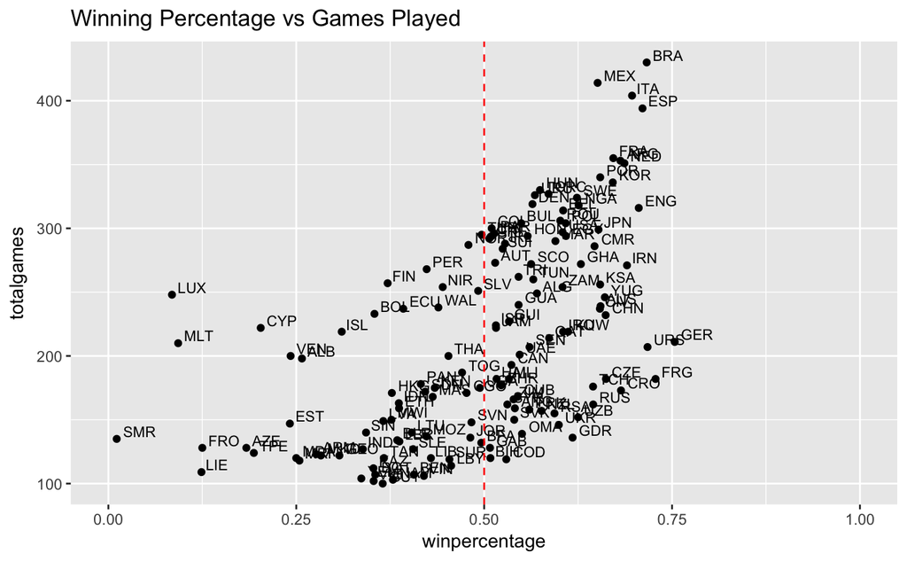

```r
# Out of the teams who have played at least 100 games, what are the winning percentages for each of those teams?
formula_winpercentage <- function(totalgames, wins, draws) {
    return ((wins + 0.5 * draws) / totalgames)
}
plot_winpercentage <- function(teamperf, mingames) {
  teamperf %>%
  group_by(name) %>%
  summarize(
    totalgames = n(),
    wins = length(w[w==TRUE]),
    draws = length(d[d==TRUE]),
    winpercentage = formula_winpercentage(totalgames, wins, draws)
  ) %>%
  filter(totalgames >= mingames ) %>%
  ggplot(mapping = aes(x = winpercentage, y = totalgames)) +
  geom_point(size = 1.5) +
  geom_text(aes(label=name), hjust=-.2 , vjust=-.2, size=3) +
  geom_vline(xintercept = .5, linetype = 2, color = "red") +
  ggtitle("Winning Percentage vs Games Played") +
  expand_limits(x = c(0,1))
}
plot_winpercentage(teamperf, 100)
```

For one thing, some countries have ceased to exist, either because they dissolved into multiple countries - for example the Soviet Union (URS), Yugoslavia (YUG) or Czechoslovakia (TCH), or because they united into one country - like it was the case with the German reunification of 1990. In the latter case, West Germany (FRG) and East Germany (GDR) unified into a single Germany (GER). Here the most impacted country is Germany.

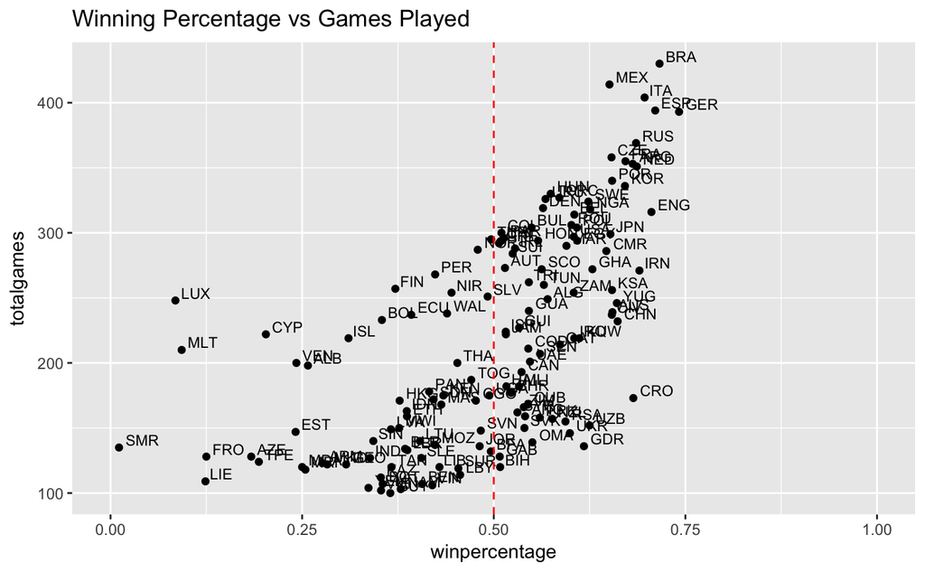

```r
# transform old country codes into new ones.
countryCodeMappings <- matrix(c(
  "FRG","GER",
  "TCH","CZE",
  "URS","RUS",
  "SCG","SRB",
  "ZAI","COD"
  ), ncol=2, byrow = TRUE)
for (i in 1:nrow(countryCodeMappings)) {
  teamperf$name[teamperf$name == countryCodeMappings[i,1]] <- countryCodeMappings[i,2]
  teamperf$opponentName[teamperf$opponentName == countryCodeMappings[i,1]] <- countryCodeMappings[i,2]

  matches$team1[matches$team1 == countryCodeMappings[i,1]] <- countryCodeMappings[i,2]
  matches$team2[matches$team2 == countryCodeMappings[i,1]] <- countryCodeMappings[i,2]
}
plot_winpercentage(teamperf, 100)
```

Let’s plot the most commun score in our dataset and the most common score in the World Cup games.

```r
# what is the occurence frequency for match scores?
scorefreq <- matches %>% filter(grepl("FIFA World Cup",CupName)) %>%
  group_by(team1Score, team2Score) %>%
  summarise(
    n = n(),
    freq = n / nrow(matches)
  ) %>%
  ungroup() %>%
  mutate(
    scoretext = paste(team1Score,"-",team2Score)
  ) %>%
  arrange(desc(freq))
  head(scorefreq, 20)
```

| team1Score | team2Score | n | freq | scoretext |
| --- | --- | --- | --- | --- |
| 1 | 1 | 704 | 0.041470311 | 1 - 1 |
| 1 | 0 | 650 | 0.038289350 | 1 - 0 |
| 0 | 1 | 628 | 0.036993402 | 0 - 1 |
| 0 | 0 | 566 | 0.033341188 | 0 - 0 |
| 2 | 0 | 499 | 0.029394439 | 2 - 0 |
| 0 | 2 | 468 | 0.027568332 | 0 - 2 |
| 1 | 2 | 452 | 0.026625825 | 1 - 2 |
| 2 | 1 | 444 | 0.026154571 | 2 - 1 |
| 0 | 3 | 303 | 0.017848728 | 0 - 3 |
| 3 | 0 | 282 | 0.016611687 | 3 - 0 |

[output cut: 10 more lines]

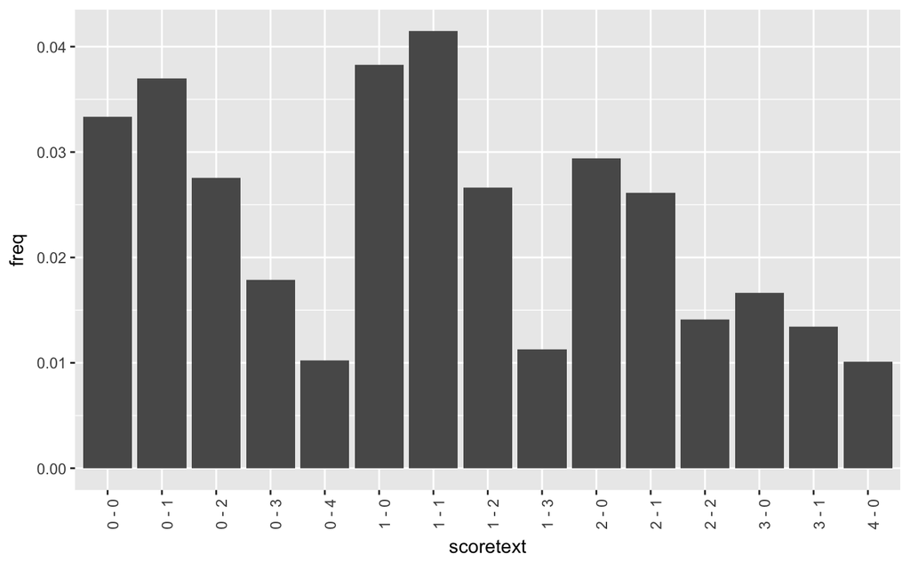

```r
  scorefreq %>%   filter(freq >= 0.01) %>% ggplot(mapping = aes(x=scoretext, y=freq)) + geom_bar(stat="identity") + theme(axis.text.x = element_text(angle = 90, hjust = 1))
```

```r
# distribution of goals scored per match
gsfreq <- matches %>% filter(grepl("FIFA World Cup",CupName)) %>%
  group_by(gs = team1Score + team2Score) %>%
  summarise(
    n = n(),
    freq = n / nrow(matches)
  ) %>%
  ungroup() %>%
  arrange(desc(freq))
head(gsfreq, 10)
```

| gs | n | freq |
| --- | --- | --- |
| 2 | 1671 | 0.098433082 |
| 3 | 1481 | 0.087240811 |
| 1 | 1278 | 0.075282752 |
| 4 | 1005 | 0.059201225 |
| 5 | 584 | 0.034401508 |
| 0 | 566 | 0.033341188 |
| 6 | 323 | 0.019026861 |
| 7 | 174 | 0.010249764 |
| 8 | 91 | 0.005360509 |
| 9 | 51 | 0.003004241 |

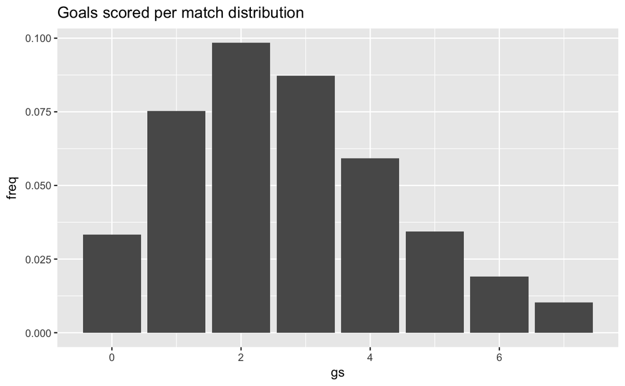

```r
gsfreq %>%
  filter(freq >= 0.01) %>%
  ggplot(mapping = aes(x = gs, y = freq)) + geom_bar(stat = "identity") + ggtitle("Goals scored per match distribution")
```

```r
# distribution of goal differential
gdfreq <- matches %>% filter(grepl("FIFA World Cup",CupName)) %>%
  group_by(gd = team1Score - team2Score) %>%
  summarise(
    n = n(),
    freq = n / nrow(matches)
  ) %>%
  ungroup() %>%
  arrange(gd)
head(gdfreq %>% filter(abs(gd)<=4), 10)
```

| gd | n | freq |
| --- | --- | --- |
| -4 | 224 | 0.01319510 |
| -3 | 432 | 0.02544769 |
| -2 | 709 | 0.04176484 |
| -1 | 1190 | 0.07009896 |
| 0 | 1549 | 0.09124647 |
| 1 | 1202 | 0.07080584 |
| 2 | 777 | 0.04577050 |
| 3 | 415 | 0.02444628 |
| 4 | 225 | 0.01325401 |

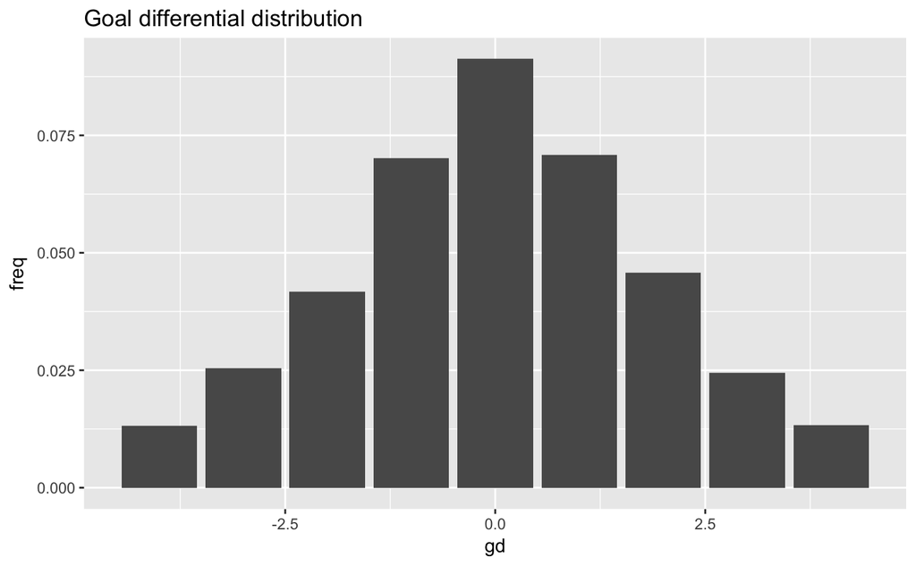

```r
gdfreq %>%
  filter(abs(gd)<=4) %>%
  ggplot(mapping = aes(x = gd, y = freq)) + geom_bar(stat = "identity") + ggtitle("Goal differential distribution")
```

## Strength of opposition

```r
# confederations and adjustment coefficients for them
confederations <- as.data.frame(matrix(c(
  "UEFA","0.99",
  "CONMEBOL","1.00",
  "CONCACAF","0.85",
  "AFC","0.85",
  "CAF","0.85",
  "OFC","0.85"
), ncol=2, byrow = TRUE, dimnames = list(NULL, c("confederation","adjust"))), stringsAsFactors = FALSE)
confederations$confederation <- as.vector(confederations$confederation)
confederations$adjust <- as.numeric(confederations$adjust)
# add a confederation coefficient for the opponent faced
teamperf <- teamperf %>%
  dplyr::left_join(teams, by=c("opponentName" = "fifa_code")) %>%
  dplyr::left_join(confederations, by=c("confederation")) %>%
  dplyr::mutate(
    opponentConfederationCoefficient = adjust
  ) %>%
dplyr::select(match_id, date, name = name.x, opponentName, opponentConfederationCoefficient,  homeVenue, neutralVenue, gs, ga, gd, w, l, d, friendly, qualifier, finaltourn)
# set missing values to 1
teamperf$opponentConfederationCoefficient[is.na(teamperf$opponentConfederationCoefficient)] <- 1
```

## Feature engineering

Now, let’s calculate some lag features for each team which is about to play a game.

We’ll look at the previous N games a team has played, up to the game in question, and we’ll calculate the percentage of wins, draws, losses, as well as the goal differential, per game, for those past N games.

For example, taking N=10:

`last10games_w_per = (number of wins in the past 10 games) / 10` `last10games_d_per = (number of draws in the past 10 games) / 10` `last10games_l_per = (number of losses in the past 10 games) / 10` `last10games_gd_per = (goals scored - goals conceeded in the past 10 games) / 10`

We’ll use three different values for N (10, 30 and 50) to capture short, medium, and long-term form.

We’ll calculate those values for every team and every game in our dataset.

```r
# Let's calculate some lag features for each team which is about to play a game
# we'll take three windows: last 5 games, last 20 games, last 35 games.
# for each window we'll calculate some values
lagfn <- function(data, width) {
  return (rollapplyr(data, width = width + 1, FUN = sum, fill = NA, partial=TRUE) - data)
}
lagfn_per <- function(data, width) {
  return (lagfn(data, width) / width)
}
team_features <- teamperf %>%
  dplyr::arrange(name, date) %>%
  dplyr::group_by(name) %>%
  dplyr::mutate(
    last10games_w_per = lagfn_per(w, 10),
    last30games_w_per = lagfn_per(w, 30),
    last50games_w_per = lagfn_per(w, 50),
    last10games_l_per = lagfn_per(l, 10),
    last30games_l_per = lagfn_per(l, 30),
    last50games_l_per = lagfn_per(l, 50),
    last10games_d_per = lagfn_per(d, 10),
    last30games_d_per = lagfn_per(d, 30),
    last50games_d_per = lagfn_per(d, 50),

    last10games_gd_per = lagfn_per(gd, 10),
    last30games_gd_per = lagfn_per(gd, 30),
    last50games_gd_per = lagfn_per(gd, 50),

    last10games_opp_cc_per = lagfn_per(opponentConfederationCoefficient, 10),
    last30games_opp_cc_per = lagfn_per(opponentConfederationCoefficient, 30),
    last50games_opp_cc_per = lagfn_per(opponentConfederationCoefficient, 50)
  ) %>%
  dplyr::select (
    match_id, date, name, opponentName, gs, ga,
    w, last10games_w_per, last30games_w_per, last50games_w_per,
    l, last10games_l_per, last30games_l_per, last50games_l_per,
    d, last10games_d_per, last30games_d_per, last50games_d_per,
    gd, last10games_gd_per, last30games_gd_per, last50games_gd_per,
    opponentConfederationCoefficient, last10games_opp_cc_per, last30games_opp_cc_per, last50games_opp_cc_per
          ) %>%
  dplyr::ungroup()
head((team_features %>% dplyr::filter(name == "BRA" & date >= '1970-01-01')), n = 20)
```

| match_id | date | name | opponentName | gs | ga | w | last10games_w_per | last30games_w_per | last50games_w_per | l | last10games_l_per | last30games_l_per | last50games_l_per | d | last10games_d_per | last30games_d_per | last50games_d_per | gd | last10games_gd_per | last30games_gd_per | last50games_gd_per | opponentConfederationCoefficient | last10games_opp_cc_per | last30games_opp_cc_per | last50games_opp_cc_per |
| --- | --- | --- | --- | --- | --- | --- | --- | --- | --- | --- | --- | --- | --- | --- | --- | --- | --- | --- | --- | --- | --- | --- | --- | --- | --- |
| 24496 | 1970-06-03 | BRA | CZE | 4 | 1 | TRUE | 0.6 | 0.5333333 | 0.58 | FALSE | 0.2 | 0.3000000 | 0.24 | FALSE | 0.2 | 0.1666667 | 0.18 | 3 | 1.8 | 0.8333333 | 0.90 | 0.99 | 0.968 | 0.9716667 | 0.9818 |
| 24504 | 1970-06-07 | BRA | ENG | 1 | 0 | TRUE | 0.7 | 0.5666667 | 0.60 | FALSE | 0.1 | 0.2666667 | 0.22 | FALSE | 0.2 | 0.1666667 | 0.18 | 1 | 2.3 | 1.0333333 | 0.98 | 0.99 | 0.968 | 0.9713333 | 0.9816 |
| 24508 | 1970-06-10 | BRA | ROU | 3 | 2 | TRUE | 0.8 | 0.5666667 | 0.60 | FALSE | 0.0 | 0.2666667 | 0.22 | FALSE | 0.2 | 0.1666667 | 0.18 | 1 | 2.5 | 1.0333333 | 0.98 | 0.99 | 0.968 | 0.9710000 | 0.9814 |
| 24516 | 1970-06-14 | BRA | PER | 4 | 2 | TRUE | 0.9 | 0.6000000 | 0.62 | FALSE | 0.0 | 0.2333333 | 0.20 | FALSE | 0.1 | 0.1666667 | 0.18 | 2 | 2.6 | 1.1333333 | 1.06 | 1.00 | 0.982 | 0.9710000 | 0.9812 |
| 24518 | 1970-06-17 | BRA | URU | 3 | 1 | TRUE | 1.0 | 0.6000000 | 0.64 | FALSE | 0.0 | 0.2333333 | 0.20 | FALSE | 0.0 | 0.1666667 | 0.16 | 2 | 2.8 | 1.1333333 | 1.10 | 1.00 | 0.997 | 0.9760000 | 0.9812 |
| 24521 | 1970-06-21 | BRA | ITA | 4 | 1 | TRUE | 1.0 | 0.6333333 | 0.64 | FALSE | 0.0 | 0.2333333 | 0.20 | FALSE | 0.0 | 0.1333333 | 0.16 | 3 | 2.8 | 1.2000000 | 1.12 | 0.99 | 0.997 | 0.9763333 | 0.9812 |
| 523 | 1972-08-27 | BRA | DEN | 2 | 3 | FALSE | 1.0 | 0.6333333 | 0.64 | TRUE | 0.0 | 0.2333333 | 0.20 | FALSE | 0.0 | 0.1333333 | 0.16 | -1 | 2.6 | 1.2666667 | 1.12 | 0.99 | 0.996 | 0.9763333 | 0.9812 |
| 532 | 1972-08-29 | BRA | HUN | 2 | 2 | FALSE | 0.9 | 0.6000000 | 0.64 | FALSE | 0.1 | 0.2666667 | 0.22 | TRUE | 0.0 | 0.1333333 | 0.14 | 0 | 2.2 | 1.1666667 | 1.10 | 0.99 | 0.995 | 0.9763333 | 0.9812 |
| 539 | 1972-08-31 | BRA | IRN | 0 | 1 | FALSE | 0.8 | 0.5666667 | 0.62 | TRUE | 0.1 | 0.2666667 | 0.22 | FALSE | 0.1 | 0.1666667 | 0.16 | -1 | 1.8 | 1.1000000 | 1.06 | 0.85 | 0.994 | 0.9760000 | 0.9812 |
| 28750 | 1974-06-13 | BRA | YUG | 0 | 0 | FALSE | 0.7 | 0.5333333 | 0.60 | FALSE | 0.2 | 0.3000000 | 0.24 | TRUE | 0.1 | 0.1666667 | 0.16 | 0 | 1.1 | 1.0000000 | 1.02 | 1.00 | 0.979 | 0.9713333 | 0.9784 |

[output cut: 10 more lines]

```r
summary(team_features)
```

```
    match_id          date                         name           opponentName             gs              ga            w
 Min.   :    1   Min.   :1950-03-08 00:00:00   Length:34191       Length:34191       Min.   : 0.00   Min.   : 0.00   Mode :logical
 1st Qu.:21053   1st Qu.:1987-02-08 00:00:00   Class :character   Class :character   1st Qu.: 0.00   1st Qu.: 0.00   FALSE:20785
 Median :25312   Median :1999-04-11 00:00:00   Mode  :character   Mode  :character   Median : 1.00   Median : 1.00   TRUE :13406
 Mean   :24655   Mean   :1995-09-21 11:36:48                                         Mean   : 1.43   Mean   : 1.44   NA's :0
 3rd Qu.:29544   3rd Qu.:2007-04-18 00:00:00                                         3rd Qu.: 2.00   3rd Qu.: 2.00
 Max.   :33783   Max.   :2016-07-10 00:00:00                                         Max.   :31.00   Max.   :31.00
 last10games_w_per last30games_w_per last50games_w_per     l           last10games_l_per last30games_l_per last50games_l_per     d
 Min.   :0.0000    Min.   :0.0000    Min.   :0.0000    Mode :logical   Min.   :0.0000    Min.   :0.0000    Min.   :0.0000    Mode :logical
 1st Qu.:0.2000    1st Qu.:0.2333    1st Qu.:0.1800    FALSE:20711     1st Qu.:0.2000    1st Qu.:0.2000    1st Qu.:0.2000    FALSE:26886
 Median :0.4000    Median :0.3667    Median :0.3600    TRUE :13480     Median :0.3000    Median :0.3333    Median :0.3000    TRUE :7305
 Mean   :0.3799    Mean   :0.3592    Mean   :0.3391    NA's :0         Mean   :0.3784    Mean   :0.3502    Mean   :0.3241    NA's :0
 3rd Qu.:0.5000    3rd Qu.:0.5000    3rd Qu.:0.4800                    3rd Qu.:0.5000    3rd Qu.:0.4667    3rd Qu.:0.4200
 Max.   :1.0000    Max.   :0.9333    Max.   :0.8800                    Max.   :1.0000    Max.   :1.0000    Max.   :1.0000
 last10games_d_per last30games_d_per last50games_d_per       gd            last10games_gd_per  last30games_gd_per last50games_gd_per
 Min.   :0.0000    Min.   :0.0000    Min.   :0.0000    Min.   :-31.00000   Min.   :-1.26e+01   Min.   :-7.53333   Min.   :-4.82000
 1st Qu.:0.1000    1st Qu.:0.1333    1st Qu.:0.1200    1st Qu.: -1.00000   1st Qu.:-6.00e-01   1st Qu.:-0.43333   1st Qu.:-0.36000
 Median :0.2000    Median :0.2000    Median :0.2000    Median :  0.00000   Median : 1.00e-01   Median : 0.16667   Median : 0.12000
 Mean   :0.2071    Mean   :0.1945    Mean   :0.1827    Mean   : -0.01053   Mean   :-1.37e-04   Mean   : 0.03032   Mean   : 0.05353
 3rd Qu.:0.3000    3rd Qu.:0.2667    3rd Qu.:0.2600    3rd Qu.:  1.00000   3rd Qu.: 8.00e-01   3rd Qu.: 0.70000   3rd Qu.: 0.68000
 Max.   :0.8000    Max.   :0.6000    Max.   :0.4800    Max.   : 31.00000   Max.   : 7.80e+00   Max.   : 4.83333   Max.   : 3.50000
 opponentConfederationCoefficient last10games_opp_cc_per last30games_opp_cc_per last50games_opp_cc_per
 Min.   :0.8500                   Min.   :0.0000         Min.   :0.0000         Min.   :0.0000
 1st Qu.:0.8500                   1st Qu.:0.8500         1st Qu.:0.8500         1st Qu.:0.7480
 Median :0.8500                   Median :0.8790         Median :0.8643         Median :0.8588
 Mean   :0.9153                   Mean   :0.8843         Mean   :0.8293         Mean   :0.7772
 3rd Qu.:0.9900                   3rd Qu.:0.9900         3rd Qu.:0.9857         3rd Qu.:0.9820
 Max.   :1.0000                   Max.   :1.0000         Max.   :1.0000         Max.   :1.0000
```

Now that we have built a series of team-specific features, we need to fold them back into match-specific features.

We will then have a set of features for both teams about to face each other.

```r
# fold per-team features into per-match features
match_features <- matches %>%
  left_join(team_features, by=c("match_id", "team1" = "name")) %>%
  left_join(team_features, by=c("match_id", "team2" = "name"), suffix=c(".t1",".t2")) %>%
  dplyr::select(
    date, match_id, team1, team2, team1Home, team2Home, neutralVenue, team1Score, team2Score, friendly, qualifier, finaltourn,
    last10games_w_per.t1,
    last30games_w_per.t1,
    last50games_w_per.t1,
    last10games_l_per.t1,
    last30games_l_per.t1,
    last50games_l_per.t1,
    last10games_d_per.t1,
    last30games_d_per.t1,
    last50games_d_per.t1,
    last10games_gd_per.t1,
    last30games_gd_per.t1,
    last50games_gd_per.t1,
    last10games_opp_cc_per.t1,
    last30games_opp_cc_per.t1,
    last50games_opp_cc_per.t1,
    last10games_w_per.t2,
    last30games_w_per.t2,
    last50games_w_per.t2,
    last10games_l_per.t2,
    last30games_l_per.t2,
    last50games_l_per.t2,
    last10games_d_per.t2,
    last30games_d_per.t2,
    last50games_d_per.t2,
    last10games_gd_per.t2,
    last30games_gd_per.t2,
    last50games_gd_per.t2,
    last10games_opp_cc_per.t2,
    last30games_opp_cc_per.t2,
    last50games_opp_cc_per.t2,
    outcome = gd.t1
  )
head(match_features)
```

| date | match_id | team1 | team2 | team1Home | team2Home | neutralVenue | team1Score | team2Score | friendly | qualifier | finaltourn | last10games_w_per.t1 | last30games_w_per.t1 | last50games_w_per.t1 | last10games_l_per.t1 | last30games_l_per.t1 | last50games_l_per.t1 | last10games_d_per.t1 | last30games_d_per.t1 | last50games_d_per.t1 | last10games_gd_per.t1 | last30games_gd_per.t1 | last50games_gd_per.t1 | last10games_opp_cc_per.t1 | last30games_opp_cc_per.t1 | last50games_opp_cc_per.t1 | last10games_w_per.t2 | last30games_w_per.t2 | last50games_w_per.t2 | … |
| --- | --- | --- | --- | --- | --- | --- | --- | --- | --- | --- | --- | --- | --- | --- | --- | --- | --- | --- | --- | --- | --- | --- | --- | --- | --- | --- | --- | --- | --- | --- |
| 1950-03-08 | 29854 | WAL | NIR | TRUE | FALSE | FALSE | 0 | 0 | FALSE | TRUE | FALSE | 0.0 | 0.00000000 | 0.00 | 0 | 0 | 0 | 0 | 0 | 0 | 0.0 | 0.00000000 | 0.00 | 0.000 | 0.000 | 0.0000 | 0 | 0 | 0 | … |
| 1950-04-02 | 29855 | ESP | POR | TRUE | FALSE | FALSE | 5 | 1 | FALSE | TRUE | FALSE | 0.0 | 0.00000000 | 0.00 | 0 | 0 | 0 | 0 | 0 | 0 | 0.0 | 0.00000000 | 0.00 | 0.000 | 0.000 | 0.0000 | 0 | 0 | 0 | … |
| 1950-04-09 | 29856 | ESP | POR | FALSE | TRUE | FALSE | 2 | 2 | FALSE | TRUE | FALSE | 0.1 | 0.03333333 | 0.02 | 0 | 0 | 0 | 0 | 0 | 0 | 0.4 | 0.13333333 | 0.08 | 0.099 | 0.033 | 0.0198 | 0 | 0 | 0 | … |
| 1950-04-15 | 29857 | ENG | SCO | FALSE | TRUE | FALSE | 1 | 0 | FALSE | TRUE | FALSE | 0.0 | 0.00000000 | 0.00 | 0 | 0 | 0 | 0 | 0 | 0 | 0.0 | 0.00000000 | 0.00 | 0.000 | 0.000 | 0.0000 | 0 | 0 | 0 | … |
| 1950-06-24 | 31013 | BRA | MEX | FALSE | FALSE | TRUE | 4 | 0 | FALSE | FALSE | TRUE | 0.0 | 0.00000000 | 0.00 | 0 | 0 | 0 | 0 | 0 | 0 | 0.0 | 0.00000000 | 0.00 | 0.000 | 0.000 | 0.0000 | 0 | 0 | 0 | … |
| 1950-06-25 | 31015 | ENG | CHI | FALSE | FALSE | TRUE | 2 | 0 | FALSE | FALSE | TRUE | 0.1 | 0.03333333 | 0.02 | 0 | 0 | 0 | 0 | 0 | 0 | 0.1 | 0.03333333 | 0.02 | 0.099 | 0.033 | 0.0198 | 0 | 0 | 0 | … |

```r
names(match_features)
```

```
 [1] "date"                      "match_id"                  "team1"                     "team2"
 [5] "team1Home"                 "team2Home"                 "neutralVenue"              "team1Score"
 [9] "team2Score"                "friendly"                  "qualifier"                 "finaltourn"
[13] "last10games_w_per.t1"      "last30games_w_per.t1"      "last50games_w_per.t1"      "last10games_l_per.t1"
[17] "last30games_l_per.t1"      "last50games_l_per.t1"      "last10games_d_per.t1"      "last30games_d_per.t1"
[21] "last50games_d_per.t1"      "last10games_gd_per.t1"     "last30games_gd_per.t1"     "last50games_gd_per.t1"
[25] "last10games_opp_cc_per.t1" "last30games_opp_cc_per.t1" "last50games_opp_cc_per.t1" "last10games_w_per.t2"
[29] "last30games_w_per.t2"      "last50games_w_per.t2"      "last10games_l_per.t2"      "last30games_l_per.t2"
[33] "last50games_l_per.t2"      "last10games_d_per.t2"      "last30games_d_per.t2"      "last50games_d_per.t2"
[37] "last10games_gd_per.t2"     "last30games_gd_per.t2"     "last50games_gd_per.t2"     "last10games_opp_cc_per.t2"
[41] "last30games_opp_cc_per.t2" "last50games_opp_cc_per.t2" "outcome"
```

```r
# drop all non-interesting columns, and those which should not be supplied for new data (like scores)
match_features <- match_features %>%
  dplyr::select(-c(match_id,team1Score,team2Score))
head(match_features)
```

| date | team1 | team2 | team1Home | team2Home | neutralVenue | friendly | qualifier | finaltourn | last10games_w_per.t1 | last30games_w_per.t1 | last50games_w_per.t1 | last10games_l_per.t1 | last30games_l_per.t1 | last50games_l_per.t1 | last10games_d_per.t1 | last30games_d_per.t1 | last50games_d_per.t1 | last10games_gd_per.t1 | last30games_gd_per.t1 | last50games_gd_per.t1 | last10games_opp_cc_per.t1 | last30games_opp_cc_per.t1 | last50games_opp_cc_per.t1 | last10games_w_per.t2 | last30games_w_per.t2 | last50games_w_per.t2 | last10games_l_per.t2 | last30games_l_per.t2 | last50games_l_per.t2 | … |
| --- | --- | --- | --- | --- | --- | --- | --- | --- | --- | --- | --- | --- | --- | --- | --- | --- | --- | --- | --- | --- | --- | --- | --- | --- | --- | --- | --- | --- | --- | --- |
| 1950-03-08 | WAL | NIR | TRUE | FALSE | FALSE | FALSE | TRUE | FALSE | 0.0 | 0.00000000 | 0.00 | 0 | 0 | 0 | 0 | 0 | 0 | 0.0 | 0.00000000 | 0.00 | 0.000 | 0.000 | 0.0000 | 0 | 0 | 0 | 0.0 | 0.00000000 | 0.00 | … |
| 1950-04-02 | ESP | POR | TRUE | FALSE | FALSE | FALSE | TRUE | FALSE | 0.0 | 0.00000000 | 0.00 | 0 | 0 | 0 | 0 | 0 | 0 | 0.0 | 0.00000000 | 0.00 | 0.000 | 0.000 | 0.0000 | 0 | 0 | 0 | 0.0 | 0.00000000 | 0.00 | … |
| 1950-04-09 | ESP | POR | FALSE | TRUE | FALSE | FALSE | TRUE | FALSE | 0.1 | 0.03333333 | 0.02 | 0 | 0 | 0 | 0 | 0 | 0 | 0.4 | 0.13333333 | 0.08 | 0.099 | 0.033 | 0.0198 | 0 | 0 | 0 | 0.1 | 0.03333333 | 0.02 | … |
| 1950-04-15 | ENG | SCO | FALSE | TRUE | FALSE | FALSE | TRUE | FALSE | 0.0 | 0.00000000 | 0.00 | 0 | 0 | 0 | 0 | 0 | 0 | 0.0 | 0.00000000 | 0.00 | 0.000 | 0.000 | 0.0000 | 0 | 0 | 0 | 0.0 | 0.00000000 | 0.00 | … |
| 1950-06-24 | BRA | MEX | FALSE | FALSE | TRUE | FALSE | FALSE | TRUE | 0.0 | 0.00000000 | 0.00 | 0 | 0 | 0 | 0 | 0 | 0 | 0.0 | 0.00000000 | 0.00 | 0.000 | 0.000 | 0.0000 | 0 | 0 | 0 | 0.0 | 0.00000000 | 0.00 | … |
| 1950-06-25 | ENG | CHI | FALSE | FALSE | TRUE | FALSE | FALSE | TRUE | 0.1 | 0.03333333 | 0.02 | 0 | 0 | 0 | 0 | 0 | 0 | 0.1 | 0.03333333 | 0.02 | 0.099 | 0.033 | 0.0198 | 0 | 0 | 0 | 0.0 | 0.00000000 | 0.00 | … |

```r
names(match_features)
```

```
 [1] "date"                      "team1"                     "team2"                     "team1Home"
 [5] "team2Home"                 "neutralVenue"              "friendly"                  "qualifier"
 [9] "finaltourn"                "last10games_w_per.t1"      "last30games_w_per.t1"      "last50games_w_per.t1"
[13] "last10games_l_per.t1"      "last30games_l_per.t1"      "last50games_l_per.t1"      "last10games_d_per.t1"
[17] "last30games_d_per.t1"      "last50games_d_per.t1"      "last10games_gd_per.t1"     "last30games_gd_per.t1"
[21] "last50games_gd_per.t1"     "last10games_opp_cc_per.t1" "last30games_opp_cc_per.t1" "last50games_opp_cc_per.t1"
[25] "last10games_w_per.t2"      "last30games_w_per.t2"      "last50games_w_per.t2"      "last10games_l_per.t2"
[29] "last30games_l_per.t2"      "last50games_l_per.t2"      "last10games_d_per.t2"      "last30games_d_per.t2"
[33] "last50games_d_per.t2"      "last10games_gd_per.t2"     "last30games_gd_per.t2"     "last50games_gd_per.t2"
[37] "last10games_opp_cc_per.t2" "last30games_opp_cc_per.t2" "last50games_opp_cc_per.t2" "outcome"
```

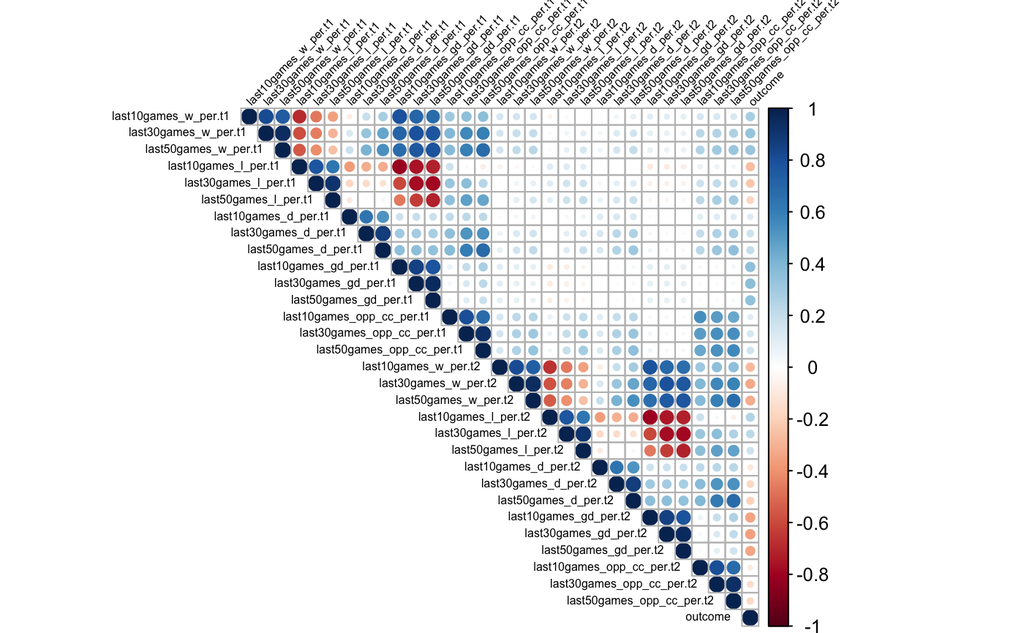

```r
# correlation matrix
cormatrix <- cor(match_features %>% dplyr::select(-c(date, team1, team2, team1Home, team2Home, neutralVenue, friendly, qualifier, finaltourn)) )
corrplot(cormatrix, type = "upper", order = "original", tl.col = "black", tl.srt = 45, tl.cex = 0.5)
```

## Training model

```r
# create the training formula
trainformula <- as.formula(paste('outcome',
                                 paste(names(match_features %>% dplyr::select(-c(date,team1,team2,outcome))),collapse=' + '),
                                 sep=' ~ '))
trainformula
```

```
outcome ~ team1Home + team2Home + neutralVenue + friendly + qualifier +
    finaltourn + last10games_w_per.t1 + last30games_w_per.t1 +
    last50games_w_per.t1 + last10games_l_per.t1 + last30games_l_per.t1 +
    last50games_l_per.t1 + last10games_d_per.t1 + last30games_d_per.t1 +
    last50games_d_per.t1 + last10games_gd_per.t1 + last30games_gd_per.t1 +
    last50games_gd_per.t1 + last10games_opp_cc_per.t1 + last30games_opp_cc_per.t1 +
    last50games_opp_cc_per.t1 + last10games_w_per.t2 + last30games_w_per.t2 +
    last50games_w_per.t2 + last10games_l_per.t2 + last30games_l_per.t2 +
    last50games_l_per.t2 + last10games_d_per.t2 + last30games_d_per.t2 +
    last50games_d_per.t2 + last10games_gd_per.t2 + last30games_gd_per.t2 +
    last50games_gd_per.t2 + last10games_opp_cc_per.t2 + last30games_opp_cc_per.t2 +
    last50games_opp_cc_per.t2
```

```r
# training and testing datasets
data.train1 <- match_features %>% dplyr::filter(date < '2009/1/1')
data.test1 <- match_features %>% dplyr::filter(date >= '2009/1/1' & date <= '2015/1/1')
nrow(data.train1)
```

```
[1] 13979
```

```r
nrow(data.test1)
```

```
[1] 2432
```

```r
# train a random forest
model.randomForest1 <- randomForest::randomForest(trainformula, data = data.train1,
                                                  importance = TRUE, ntree = 500)
model.randomForestFinal <- randomForest::randomForest(trainformula, data = rbind(data.train1,data.test1),
                                                  importance = TRUE, ntree = 500)
summary(model.randomForest1)
```

```
                Length Class  Mode
call                5  -none- call
type                1  -none- character
predicted       13979  -none- numeric
mse               500  -none- numeric
rsq               500  -none- numeric
oob.times       13979  -none- numeric
importance         72  -none- numeric
importanceSD       36  -none- numeric
localImportance     0  -none- NULL
proximity           0  -none- NULL
ntree               1  -none- numeric
mtry                1  -none- numeric
forest             11  -none- list
coefs               0  -none- NULL
y               13979  -none- numeric
test                0  -none- NULL
inbag               0  -none- NULL
terms               3  terms  call
```

## Model evaluation

```r
randomForest::importance(model.randomForest1, type=1)
```

```
                           %IncMSE
team1Home                 50.74144
team2Home                 53.30713
neutralVenue              20.23597
friendly                   0.00000
qualifier                 12.25156
finaltourn                11.03702
last10games_w_per.t1      20.64257
last30games_w_per.t1      26.08569
last50games_w_per.t1      26.87991
last10games_l_per.t1      13.77207
last30games_l_per.t1      24.80146
last50games_l_per.t1      20.85388
last10games_d_per.t1      15.18544
last30games_d_per.t1      24.88110
last50games_d_per.t1      25.90117
last10games_gd_per.t1     28.59622
last30games_gd_per.t1     28.92407
last50games_gd_per.t1     28.92934
last10games_opp_cc_per.t1 30.77311
last30games_opp_cc_per.t1 32.42522
last50games_opp_cc_per.t1 33.24185
last10games_w_per.t2      12.16764
last30games_w_per.t2      25.84188
last50games_w_per.t2      25.89726
last10games_l_per.t2      13.16164
last30games_l_per.t2      24.67821
last50games_l_per.t2      32.94791
last10games_d_per.t2      17.83790
last30games_d_per.t2      21.73085
last50games_d_per.t2      20.59151
last10games_gd_per.t2     23.54468
last30games_gd_per.t2     27.17906
last50games_gd_per.t2     36.52126
last10games_opp_cc_per.t2 25.12303
last30games_opp_cc_per.t2 26.94743
last50games_opp_cc_per.t2 34.35229
```

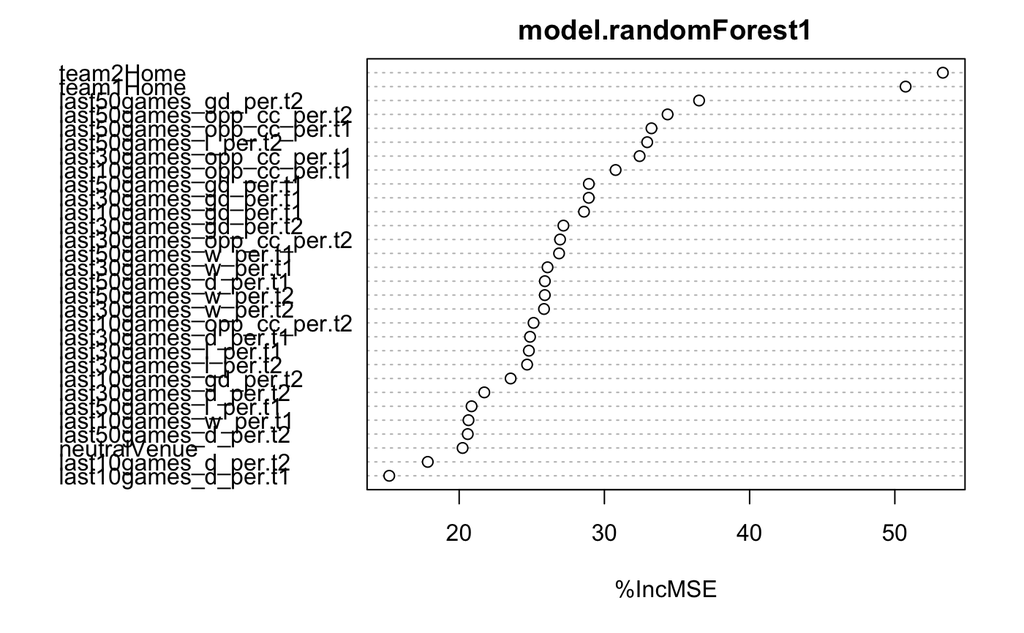

```r
randomForest::varImpPlot(model.randomForest1, type=1)
```

We can now expose our trained model to the test dataset, and calculate indicators related to its accuracy.

```r
data.pred.randomForest1 <- predict(model.randomForest1, data.test1, predict.all = TRUE)
metrics.randomForest1.mae <- Metrics::mae(data.test1$outcome, data.pred.randomForest1$aggregate)
metrics.randomForest1.rmse <- Metrics::rmse(data.test1$outcome, data.pred.randomForest1$aggregate)
paste("Mean Absolute Error:", metrics.randomForest1.mae)
```

```
[1] "Mean Absolute Error: 1.32248204495614"
```

```r
paste("Root Mean Square Error:",metrics.randomForest1.rmse)
```

```
[1] "Root Mean Square Error: 1.77978936948205"
```

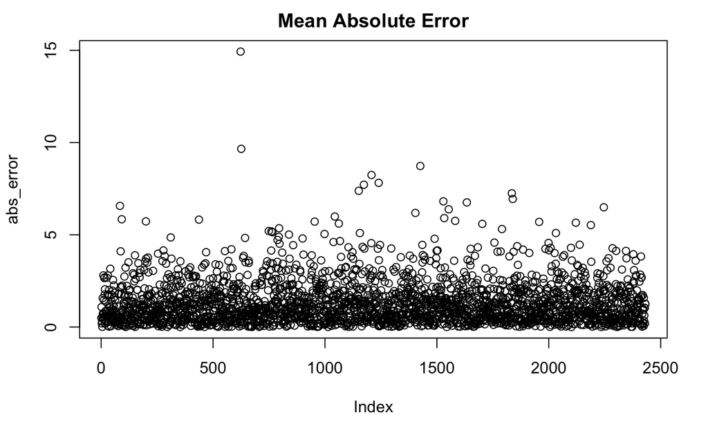

```r
abs_error <- abs(data.test1$outcome - data.pred.randomForest1$aggregate)
plot(abs_error, main="Mean Absolute Error")
```

## Simulating the tournament

```r
qualified <- read_csv("wc2018qualified.csv")
```

We will generate all the the possible two-team combinations, then ask the model for predictions for each combination, and then store those predictions.We can store the mean values, as well as the standard deviation of the predicted values from every one of our decision trees. This will allow us to simulate a more realistic distribution of results, for multiple iterations of the same match.

```r
# get a list of possible matches to be played at the world cup
data.topredict <- expand.grid(team1 = qualified$name, team2 = qualified$name, stringsAsFactors = FALSE) %>% filter(team1 < team2)
temp <- teamperf %>%
  semi_join(qualified, by = c("name")) %>%
  group_by(name) %>%
  summarise(
    date = max(date)
  )
temp <- team_features %>%
  semi_join(temp, by = c("name", "date"))
# calculate the features for every possbile match
data.topredict <- data.topredict %>%
  left_join(temp, by = c("team1" = "name")) %>%
  left_join(temp, by = c("team2" = "name"), suffix = c(".t1", ".t2")) %>%
  dplyr::select(
    team1, team2,
    last10games_w_per.t1,
    last30games_w_per.t1,
    last50games_w_per.t1,
    last10games_l_per.t1,
    last30games_l_per.t1,
    last50games_l_per.t1,
    last10games_d_per.t1,
    last30games_d_per.t1,
    last50games_d_per.t1,
    last10games_gd_per.t1,
    last30games_gd_per.t1,
    last50games_gd_per.t1,
    last10games_opp_cc_per.t1,
    last30games_opp_cc_per.t1,
    last50games_opp_cc_per.t1,
    last10games_w_per.t2,
    last30games_w_per.t2,
    last50games_w_per.t2,
    last10games_l_per.t2,
    last30games_l_per.t2,
    last50games_l_per.t2,
    last10games_d_per.t2,
    last30games_d_per.t2,
    last50games_d_per.t2,
    last10games_gd_per.t2,
    last30games_gd_per.t2,
    last50games_gd_per.t2,
    last10games_opp_cc_per.t2,
    last30games_opp_cc_per.t2,
    last50games_opp_cc_per.t2
  ) %>%
  mutate(
    date = as.POSIXct("2018-06-14"),
    team1Home = (team1 == "RUS"), team2Home = (team2 == "RUS"), neutralVenue = !(team1Home | team2Home),
    friendly = FALSE, qualifier = FALSE, finaltourn = TRUE
  )
head(data.topredict)
```

|  | team1 | team2 | last10games_w_per.t1 | last30games_w_per.t1 | last50games_w_per.t1 | last10games_l_per.t1 | last30games_l_per.t1 | last50games_l_per.t1 | last10games_d_per.t1 | last30games_d_per.t1 | last50games_d_per.t1 | last10games_gd_per.t1 | last30games_gd_per.t1 | last50games_gd_per.t1 | last10games_opp_cc_per.t1 | last30games_opp_cc_per.t1 | last50games_opp_cc_per.t1 | last10games_w_per.t2 | last30games_w_per.t2 | last50games_w_per.t2 | last10games_l_per.t2 | last30games_l_per.t2 | last50games_l_per.t2 | last10games_d_per.t2 | last30games_d_per.t2 | last50games_d_per.t2 | last10games_gd_per.t2 | last30games_gd_per.t2 | last50games_gd_per.t2 | … |
| --- | --- | --- | --- | --- | --- | --- | --- | --- | --- | --- | --- | --- | --- | --- | --- | --- | --- | --- | --- | --- | --- | --- | --- | --- | --- | --- | --- | --- | --- | --- |
| 1 | KSA | RUS | 0.8 | 0.5000000 | 0.54 | 0.0 | 0.2000000 | 0.18 | 0.2 | 0.3000000 | 0.28 | 2.5 | 0.9666667 | 0.92 | 0.880 | 0.8600000 | 0.8560 | 0.4 | 0.5 | 0.56 | 0.3 | 0.2333333 | 0.24 | 0.3 | 0.2666667 | 0.2 | 0.8 | 1.166667 | 1.02 | … |
| 2 | EGY | RUS | 0.5 | 0.4666667 | 0.54 | 0.4 | 0.4000000 | 0.34 | 0.1 | 0.1333333 | 0.12 | 0.8 | 0.2666667 | 0.50 | 0.850 | 0.8596667 | 0.8616 | 0.4 | 0.5 | 0.56 | 0.3 | 0.2333333 | 0.24 | 0.3 | 0.2666667 | 0.2 | 0.8 | 1.166667 | 1.02 | … |
| 3 | POR | RUS | 0.6 | 0.6000000 | 0.60 | 0.0 | 0.1000000 | 0.14 | 0.4 | 0.3000000 | 0.26 | 0.7 | 0.6333333 | 0.84 | 0.990 | 0.9806667 | 0.9790 | 0.4 | 0.5 | 0.56 | 0.3 | 0.2333333 | 0.24 | 0.3 | 0.2666667 | 0.2 | 0.8 | 1.166667 | 1.02 | … |
| 4 | ESP | RUS | 0.9 | 0.7333333 | 0.74 | 0.1 | 0.1666667 | 0.14 | 0.0 | 0.1000000 | 0.12 | 1.6 | 1.5000000 | 1.54 | 0.990 | 0.9723333 | 0.9712 | 0.4 | 0.5 | 0.56 | 0.3 | 0.2333333 | 0.24 | 0.3 | 0.2666667 | 0.2 | 0.8 | 1.166667 | 1.02 | … |
| 5 | MAR | RUS | 0.7 | 0.4000000 | 0.50 | 0.2 | 0.2666667 | 0.22 | 0.1 | 0.3333333 | 0.28 | 0.9 | 0.4666667 | 0.70 | 0.850 | 0.8546667 | 0.8528 | 0.4 | 0.5 | 0.56 | 0.3 | 0.2333333 | 0.24 | 0.3 | 0.2666667 | 0.2 | 0.8 | 1.166667 | 1.02 | … |
| 6 | IRN | RUS | 0.5 | 0.6000000 | 0.54 | 0.2 | 0.1333333 | 0.12 | 0.3 | 0.2666667 | 0.34 | 1.8 | 1.6333333 | 1.22 | 0.879 | 0.8596667 | 0.8558 | 0.4 | 0.5 | 0.56 | 0.3 | 0.2333333 | 0.24 | 0.3 | 0.2666667 | 0.2 | 0.8 | 1.166667 | 1.02 | … |

```r
# ask the model to predict our world cup matches
data.predicted <- predict(model.randomForestFinal, data.topredict, predict.all = TRUE)
head(data.predicted)
```

[output not shown]

[output cut: 205 more lines]

[output not shown]

So, for every game in our input dataset, we’ve got the individual predictions from every one of our 500 decision trees, as well as the mean value of those predictions.

We’re going to save the mean values, as well as the standard deviation of the 500 individual predictions. The standard deviation is a measure of how “dispersed” our values are; in other words, how close (or far away from) the mean the individual values are.

```r
# calculate the standard deviation of the individual predictions of each match
data.predicted$sd = apply(data.predicted$individual, c(1), sd)
# keep only the interesting columns for running tournament simulations
data.staticpred <- data.topredict %>%
  dplyr::select(team1, team2)
data.staticpred$outcome = data.predicted$aggregate
data.staticpred$sd = data.predicted$sd
head(data.staticpred)
```

|  | team1 | team2 | outcome | sd |
| --- | --- | --- | --- | --- |
| 1 | KSA | RUS | -0.7448667 | 1.702713 |
| 2 | EGY | RUS | -1.4094333 | 1.963986 |
| 3 | POR | RUS | -0.0995000 | 1.660335 |
| 4 | ESP | RUS | 0.4665333 | 1.549829 |
| 5 | MAR | RUS | -1.3583000 | 1.752596 |
| 6 | IRN | RUS | -0.5684667 | 1.750179 |

We can use the mean and standard deviation values to pick an individual outcome for a match. For example, we can use the normal distribution in conjunction with R’s rnorm function to pick an outcome for a match where we have obtained a predicted mean and standard deviation from the model.

```r
teamA <- "GER"
teamB <- "FRA"
temp <- data.staticpred %>% dplyr::filter(team1 == teamA & team2 == teamB)
if(nrow(temp) == 0){
  tempTeam <- teamA
  teamA <- teamB
  teamB <- tempTeam
  temp <- data.staticpred %>% dplyr::filter(team1 == teamA & team2 == teamB)
}
temp
```

| team1 | team2 | outcome | sd |
| --- | --- | --- | --- |
| FRA | GER | 0.0534 | 1.711322 |

```r
set.seed(4342)
draw_threshold <- 0.5575
temp2 <- rnorm(100, temp$outcome, temp$sd)
temp2
```

```
  [1]  0.1191140904  0.2665431836  3.0778965077 -2.7202261850 -1.4622365984 -3.0198410887 -0.1596831006  3.1219224741  0.3220176816
 [10]  0.0495492501 -0.9950798321  0.2944295089 -2.6348965619 -1.8296088807 -2.9651322763 -0.8448429506 -0.0001734569  0.4957055070
 [19]  1.8859908276  3.5357606051  0.2721699454 -0.3786122899  1.4854514149  1.0083165254  2.0108560976 -0.5124595521 -0.6342194775
 [28]  2.1909889677  0.4442110672 -1.1407066737 -2.7322010091 -0.9519332983 -0.7564535000  0.7055444083  1.3733549700  0.5026754526
 [37]  1.9333498579 -1.0225234169  0.0881249733  2.6512866097  1.9306508405 -1.1304330834 -1.6981512400 -0.4961704170 -1.0487476832
 [46]  0.8664913223 -2.0759420840  0.7612215867 -1.3407548292  1.6429138278  2.1506794606 -0.6253513251  1.6440287460 -0.3781693794
 [55]  0.4505021511 -1.1134334523 -0.2284384537 -0.0643249769  1.5472308692 -1.1382744033 -4.8419426691  0.4215412109  2.1009071010
 [64]  1.1591728709  1.2943206250 -2.9657665574 -0.1493036025 -2.9036385042 -0.1028132952 -1.4723544658 -0.0936138277  0.4616590161
 [73]  5.0238152545  0.3305553487 -1.2815646682  2.1386332446 -0.1726949568 -0.8526092889  1.2318502196 -2.0586311415  1.5308993410
 [82]  0.8972375133  3.9121636387 -1.4754016968  0.0337470475  3.8803068492  0.6241424567  0.7148624582  2.1752122834  1.7192011735
 [91] -0.2847212114 -1.2199045318 -1.6235843046  1.8162414068 -0.0863027235 -1.0500454123 -0.9325314901 -2.3646042320  2.3025818154
[100]  2.4667681070
```

```r
plot(round(temp2),xlab="Match Index",ylab="Goal Diff", main=paste(teamA,"vs",teamB, "100 simulated matches"))
abline(h = 0, v = 0, col = "gray60")
```

```r
abline(h = -0.4475, v = 0, col = "gray60", lty=3)
abline(h = +0.4475, v = 0, col = "gray60", lty=3)
```

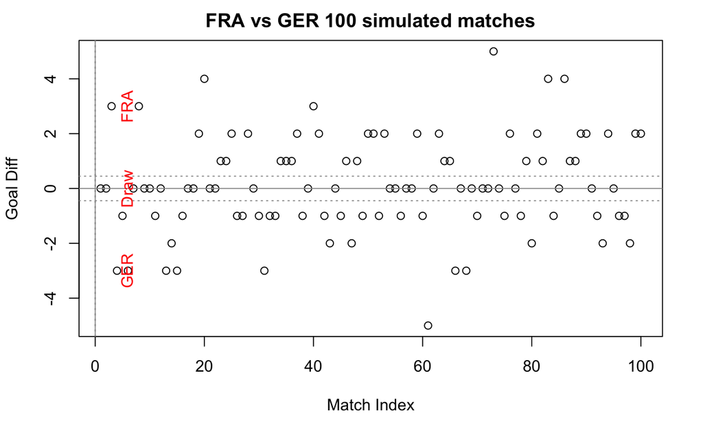

```r
mtext(c(teamB,"Draw",teamA),side=2,line=-3,at=c(-3,0,3),col= "red")
```

```r
paste(teamA," won", length(temp2[temp2 > +draw_threshold]), "matches.")
```

```
[1] "FRA  won 36 matches."
```

```r
paste(teamB," won", length(temp2[temp2 < -draw_threshold]), "matches.")
```

```
[1] "GER  won 35 matches."
```

```r
paste(length(temp2[temp2 >= -draw_threshold & temp2 <= +draw_threshold]), "matches drawn.")
```

```
[1] "29 matches drawn."
```

```r
predict_win <- function(team1,team2,draw_threshold=0.4475) {
  teamA <- team1
  teamB <- team2
  temp <- data.staticpred %>% dplyr::filter(team1 == teamA & team2 == teamB)
  if(nrow(temp) == 0){
    tempTeam <- teamA
    teamA <- teamB
    teamB <- tempTeam
    temp <- data.staticpred %>% dplyr::filter(team1 == teamA & team2 == teamB)
  }
  set.seed(4342)
  temp2 <- rnorm(100, temp$outcome, temp$sd)
  l <- list(teamA,teamB,length(temp2[temp2 < -draw_threshold]),length(temp2[temp2 > +draw_threshold]),length(temp2[temp2 >= -draw_threshold & temp2 <= +draw_threshold]))
  #print(paste(teamA," won", length(temp2[temp2 > +draw_threshold]), "matches."))
  #print(paste(teamB," won", length(temp2[temp2 < -draw_threshold]), "matches."))
  #print(paste(length(temp2[temp2 >= -draw_threshold & temp2 <= +draw_threshold]), "matches drawn."))
  return(l)
}
```

```r
equipe <- data.staticpred[,c("team1","team2")]
for(row in 1:nrow(equipe)){
  l <- predict_win(equipe[row,"team1"],equipe[row,"team2"])
  results[row,"teamA"] <-  l[1]
  results[row,"teamB"] <-  l[2]
  results[row,"teamA_win"] <- l[4]
  results[row,"teamB_win"] <- l[3]
  results[row,"draw"] <- l[5]
}
```

# Find a draw treshold

In order to find a draw treshold we used the gris search method to find the treshold that maximize our performance, in our case the treshold that minimize the mean absolute error

```r
mae_vector <- c()
threshold_seq <- seq(from=0, to = 1, by = 0.01)
for(threshold in threshold_seq){
  temp_data <- as.vector(data.pred.randomForest1$aggregate)
  temp_data <- with(data.frame(x = temp_data), replace(x, temp_data >= -threshold & temp_data <= threshold, 0))
  metrics.randomForest1.mae <- Metrics::mae(data.test1$outcome, temp_data)
  mae_vector <- c(mae_vector,metrics.randomForest1.mae)
}
best_treshold_index <- which.min(mae_vector)
best_threshold <- threshold_seq[best_treshold_index]
sprintf("The best threshold is : %f",best_threshold)
```

```
[1] "The best threshold is : 0.400000"
```

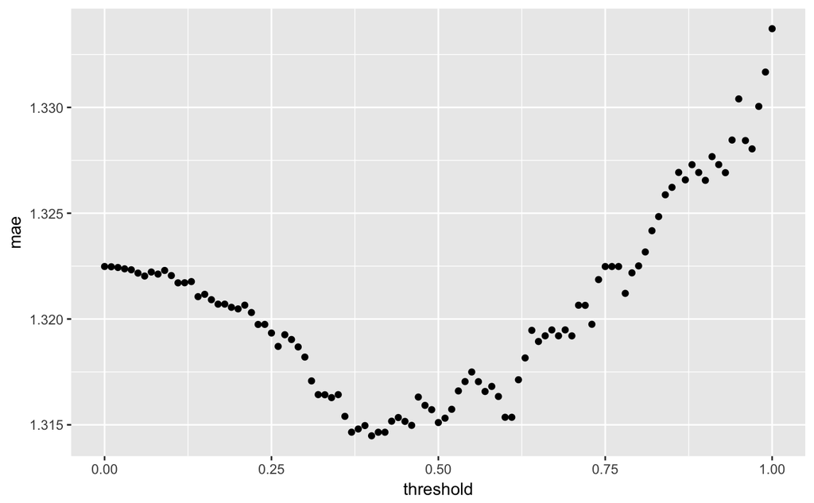

```r
df <- data.frame(threshold = threshold_seq, mae = mae_vector)
p <- ggplot(data=df, aes(x=threshold, y=mae)) + geom_point()
p
```